# The PBTM R-Package

Pedro Bello and Kent Bradford

## Overview

#### Population-based Threshold Models (PBTM) Calculator - beta version.

This R package combines existing PBTMs calculation, parameters output and respective plots.

## Installation

Installation of the package requires the “devtools” package.

#### Install development version from Github

```r
devtools::install_github("pedrobello/PBTM")
```

#### Load package

```r
library("PBTM")
```

## Data preparation steps

Before using the PBTM package, data preparation and selection is required. Main steps are described below.

- Download the template file (download PBTM-R-Dt-Empty.csv or the example file PBTM-R-Dt-Sample.csv).
- Enter your data in the proper field and leave unsed columns in blank. Repeat the treatment information for all data points of that treatment. Description of all fields present in the template file in the table below.

| Field | Description | Type | Requirement |
| --- | --- | --- | --- |
| Treat.ID | Treatment unique number | Sequential numeric field | All models |
| Treat.desc | Description of the lot and treatment. | Text field | All models |
| Treat.aging.time | Aging time | Number (0-positive) | Aging Model |
| Treat.priming.wp | Measured water potential used during priming | Number (0-negative) | Priming models (hydropriming and hydrothermal priming) |
| Treat.priming.temp | Measured temperature during priming | Number (0-negative) | Hydrothermal priming model |
| Treat.priming.duration | Priming duration | Number (hours or days) | Priming models (hydropriming and hydrothermal priming) |
| Germ.wp | Measured germination water potential | Number (0-negative) | Hydrotime and Hydrothermal models |
| Germ.temp | Measured germination temperature | Number (temperature in celsius) | Thermaltime and hydrothermal models |
| Germ.promoter.dosage | Measured concentration of the germination promoter | Number (0-positive) | Promoter model |
| Germ.inhibitor.dosage | Measured concentration of the germination inhibitor | Number (0-positive) | Inhibitor model |
| Germ.time.hours | Germination time | Number (hours) | All models |
| Germ.pct | Germination percentage | Number (percentage 0-100) | All models |
| Germ.fraction | Germination fraction | Number (fraction 0-1) | All models |

- Inform your working folder in R. Add the folder location of your data files.

```r
setwd("~/MyProjectFolder/MyDataFolder")
```

- Load Seeds data - Add the name of the data file (csv file)

```r
mydata <- read.csv("PBTM-R-Data-MyData.csv", header=T)
```

- In case the data file has more treatments than you wish to use on a partiular model calculation, filter only the data that will be used to calculate that particular model. Some examples:
  - Thermal time model: Select only treatments with germination tested in water (wp = 0) for a particular seed lot (Treat.ID = 1)

    ```r
    TreatData <- subset(mydata, Treat.ID == 1 & Germ.wp==0)
    ```

  - Hydrotime model: Select only treatments with germination tested in a certain temperature (temp = 25C) for a particular seed lot (Treat.ID = 1)

    ```r
    TreatData <- subset(mydata, Treat.ID == 1 & Germ.temp==25)
    ```

  - Hydrothermal time suboptimal model: Select only treatments with germination tested in a certain temperature range (temp < 26C) for a particular seed lot (Treat.ID = 1)

    ```r
    TreatData <- subset(mydata, Treat.ID == 1 & Germ.temp < 26)
    ```

- Whenever the data file is already filtered only with the data to be used in the model calculation, reference the filtered data to the TreatData data table (step already perfomed above when data filtering is required).

```r
TreatData <- mydata
```

## Model Selection

After the data to be used in the model calculation is passed to the TreatData table, now define the model to be calculated. Currently, the following models are available for calculation:

[output not shown]

The model is selected using the function “DefineModel()” with the respective code of the model as described above. Examples below.

Selection of the thermal time suboptimal model:

```r
DefineModel(1.1)
```

Selection of the hydrothermal time suboptimal model:

```r
DefineModel(3.1)
```

## Basic Functions

### PlotRawData()

Plot your raw data to be used on model. Cumulative germination (or other measured signal) curves will be plotted against time in hours. Treatments legend will be created based on the selected model. The data to be used on the models and plotted here must be referenced to the **TreatData** data table.

```r
data(TomatoQ2Dt)
TreatData <- subset(TomatoQ2Dt, Treat.ID == 1 & Germ.wp==0)
DefineModel(1.1)
```

```
## [1] "Thermal time suboptimal model selected"
```

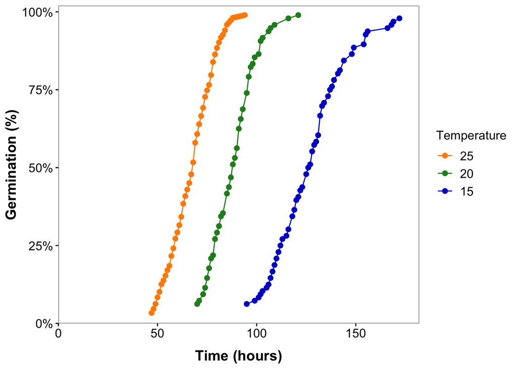

```r
PlotRawData()
```

Example of raw data for the thermal time model. Population oxygen depletion (POD) curves for tomato seeds at suboptimal temperatures (25, 20 and 15C). Bello and Bradford (2016) Seed Science Research 26(3) 199–221.

### CalcT50nGR50()

Calculates the time to 50% germination (T50) and the germination rate (GR50) and separates the treatments based on the TreatData file. Treatments and calculated parameters are delivered to the **Treatments** data file.

```r
CalcT50nGR50()
```

| Treat.ID | Treat.desc | Germ.wp | Germ.temp | T50 | GR50 |
| --- | --- | --- | --- | --- | --- |
| 1 | Tomato-15C-Water | 0 | 15 | 126.00000 | 0.0079365 |
| 1 | Tomato-20C-Water | 0 | 20 | 87.75000 | 0.0113960 |
| 1 | Tomato-25C-Water | 0 | 25 | 67.55989 | 0.0148017 |

### CleanGermData()

Clean repetitive percentages on the cumulative curves to be used in the selected models. Data present of the **TreatData** file is processed (it keeps only initial germination observation and remove points where no increase was observed). This function sends the clean and processed data to the **TreatDataClean** data file and plots the result.

```r
CleanGermData()
```

[output not shown]

## Model Calculation and plot

The Function **CALCnPLOTModel()** calculates model parameters and plot raw and curves predicted by the selected model. Additionaly, model parameters and correlations values are informed in the plot.

### Thermal time suboptimal model

```r
TreatData <- subset(TomatoQ2Dt, Treat.ID == 1 & Germ.wp==0)
DefineModel(1.1)
```

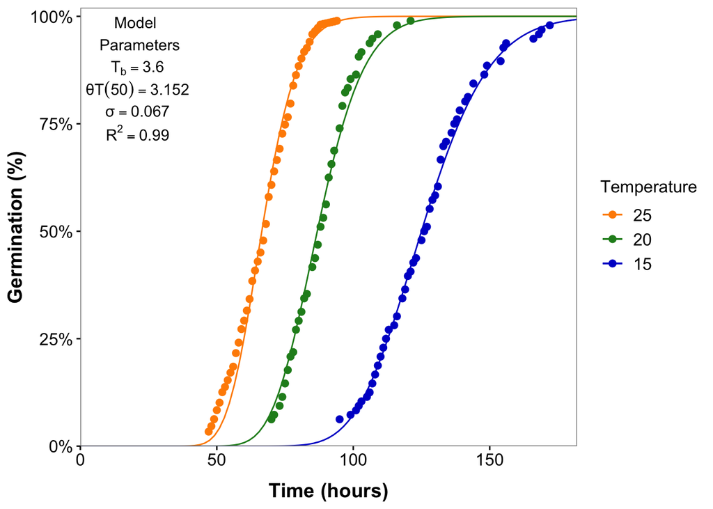

```r
CALCnPLOTModel()
```

Example of calculated thermal time model with raw data, predicted curves and calculated parameters. Bello and Bradford (2016) Seed Science Research 26(3) 199–221.

### Hydrotime suboptimal model

```r
TreatData <- subset(TomatoQ2Dt, Treat.ID == 1 & Germ.temp==25)
DefineModel(2.1)
```

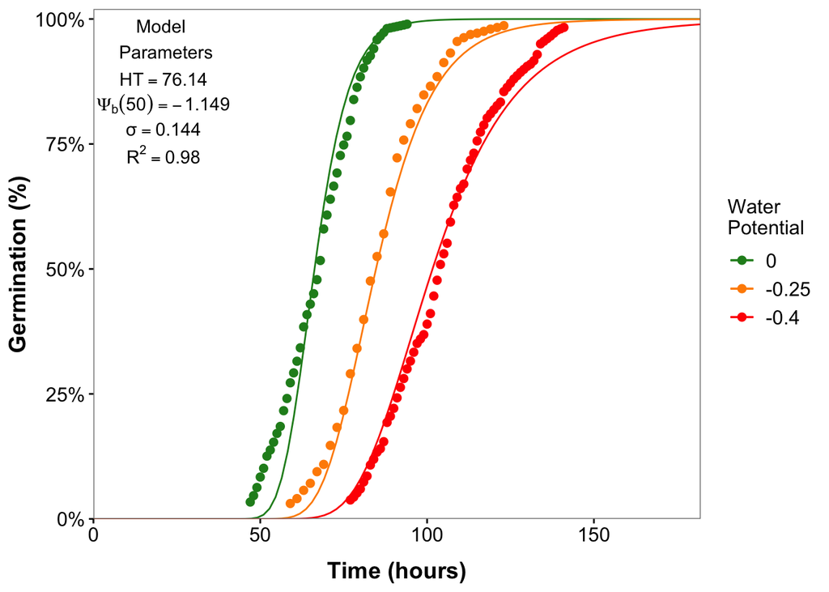

```r
CALCnPLOTModel()
```

Example of calculated hydrotime model at 25C with raw data, predicted curves and calculated parameters. Bello and Bradford (2016) Seed Science Research 26(3) 199–221.

```r
TreatData <- subset(TomatoQ2Dt, Treat.ID == 1 & Germ.temp==25)
DefineModel(2.1)
```

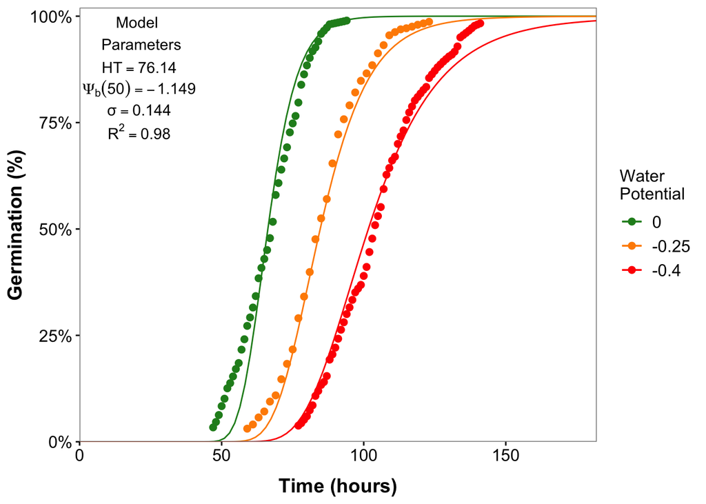

```r
CALCnPLOTModel()
```

### Hydrothermal time suboptimal model

```r
TreatData <- subset(TomatoQ2Dt, Treat.ID == 1)
DefineModel(3.1)
```

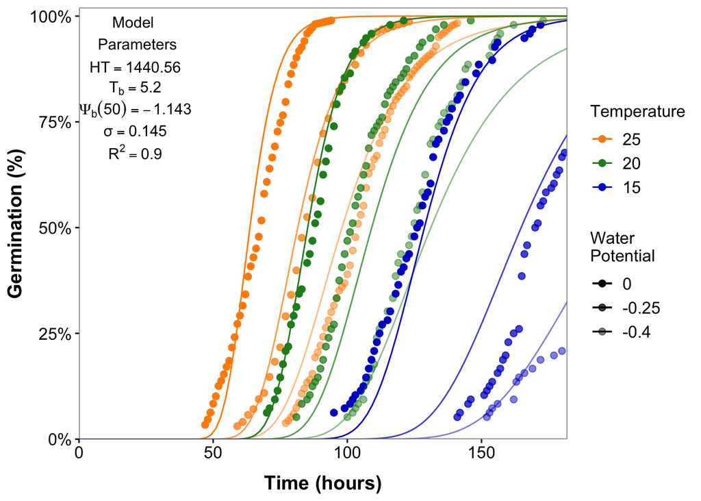

```r
CALCnPLOTModel()
```

Example of calculated hydrothermal time model with raw data, predicted curves and calculated parameters. Bello and Bradford (2016) Seed Science Research 26(3) 199–221.

### Hydropriming model

```r
data(PrimingDt)
TreatData <- subset(PrimingDt, Treat.priming.temp == 20 | Treat.priming.temp == 0)
DefineModel(6.1)
```

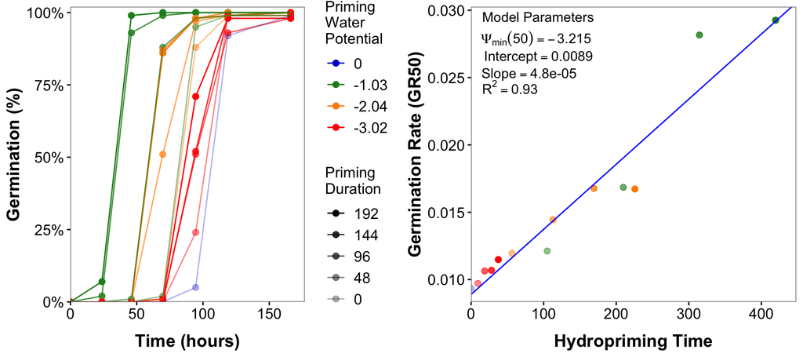

```r
CALCnPLOTModel()
```

### Hydrothermal priming model

```r
TreatData <- PrimingDt
DefineModel(6.2)
```

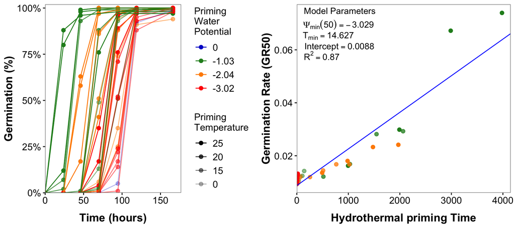

```r
CALCnPLOTModel()
```